# Healthcare diabetic project

# Naive Bayes

```python
from sklearn.naive_bayes import GaussianNB
Classification_Kfold_GNB =GaussianNB()
Classification_Kfold_GNB.fit(X_train_fold,y_train_fold)
```

```
GaussianNB(priors=None, var_smoothing=1e-09)
```

```python
y_pred_NB_kfold = Classification_Kfold_GNB.predict(X_test_fold)
```

```python
from sklearn.metrics import confusion_matrix,accuracy_score,precision_score,recall_score,f1_score
cm_kfold_NB=confusion_matrix(y_pred_NB_kfold,y_test_fold)
accuracy_kfold_NB = accuracy_score(y_pred_NB_kfold,y_test_fold)
precision_kfold_NB =precision_score(y_pred_NB_kfold,y_test_fold)
recall_kfold_NB = recall_score(y_pred_NB_kfold,y_test_fold)
F1score_kfold_NB =f1_score(y_pred_NB_kfold,y_test_fold)
print(cm_kfold_NB)
print("Accuracy{} and Precission:{} and Recall:{} and F1score:{}".format(accuracy_kfold_NB,precision_kfold_NB,recall_kfold_NB,F1score_kfold_NB))
```

```
[[56 25]
 [11 17]]
Accuracy0.6697247706422018 and Precission:0.40476190476190477 and Recall:0.6071428571428571 and F1score:0.4857142857142857
```

# Naive Bayes has Better accuracy and F1 score in comaprison with logisticsRegression and SVM

# KNN (K-Nearest Neighbour)

```python
from sklearn.neighbors import KNeighborsClassifier
Classifier_kfold_KNN = KNeighborsClassifier()
Classifier_kfold_KNN.fit(X_train_fold,y_train_fold)
```

```
KNeighborsClassifier(algorithm='auto', leaf_size=30, metric='minkowski',
                     metric_params=None, n_jobs=None, n_neighbors=5, p=2,
                     weights='uniform')
```

```python
y_pred_KNN_kfold = Classifier_kfold_KNN.predict(X_test_fold)
```

```python
from sklearn.metrics import confusion_matrix,accuracy_score,precision_score,recall_score,f1_score
cm_kfold_KNN=confusion_matrix(y_pred_KNN_kfold,y_test_fold)
accuracy_kfold_KNN = accuracy_score(y_pred_KNN_kfold,y_test_fold)
precision_kfold_KNN =precision_score(y_pred_KNN_kfold,y_test_fold)
recall_kfold_KNN = recall_score(y_pred_KNN_kfold,y_test_fold)
F1score_kfold_KNN =f1_score(y_pred_KNN_kfold,y_test_fold)
print(cm_kfold_KNN)
print("Accuracy{} and Precission:{} and Recall:{} and F1score:{}".format(accuracy_kfold_KNN,precision_kfold_KNN,recall_kfold_KNN,F1score_kfold_KNN))
```

```
[[58 26]
 [ 9 16]]
Accuracy0.6788990825688074 and Precission:0.38095238095238093 and Recall:0.64 and F1score:0.4776119402985074
```

KNN has better accuracy but smaller F1 Score in comparison with Naive Bayes

# Decision Tree classifier

```python
from sklearn.tree import DecisionTreeClassifier
Clasifier_kfold_DecisionTree = DecisionTreeClassifier(random_state=42)
Clasifier_kfold_DecisionTree.fit(X_train_fold,y_train_fold)
```

```
DecisionTreeClassifier(ccp_alpha=0.0, class_weight=None, criterion='gini',
                       max_depth=None, max_features=None, max_leaf_nodes=None,
                       min_impurity_decrease=0.0, min_impurity_split=None,
                       min_samples_leaf=1, min_samples_split=2,
                       min_weight_fraction_leaf=0.0, presort='deprecated',
                       random_state=42, splitter='best')
```

```python
y_pred_fold_DT = Clasifier_kfold_DecisionTree.predict(X_test_fold)
```

```python
from sklearn.metrics import confusion_matrix,accuracy_score,precision_score,recall_score,f1_score
cm_kfold_DT=confusion_matrix(y_pred_fold_DT,y_test_fold)
accuracy_kfold_DT = accuracy_score(y_pred_fold_DT,y_test_fold)
precision_kfold_DT =precision_score(y_pred_fold_DT,y_test_fold)
recall_kfold_DT = recall_score(y_pred_fold_DT,y_test_fold)
F1score_kfold_DT =f1_score(y_pred_fold_DT,y_test_fold)
print(cm_kfold_DT)
print("Accuracy{} and Precission:{} and Recall:{} and F1score:{}".format(accuracy_kfold_DT,precision_kfold_DT,recall_kfold_DT,F1score_kfold_DT))
```

```
[[49 21]
 [18 21]]
Accuracy0.6422018348623854 and Precission:0.5 and Recall:0.5384615384615384 and F1score:0.5185185185185186
```

# Random Forest classifier

```python
from sklearn.ensemble import RandomForestClassifier
Classifier_kfold_rf =RandomForestClassifier(random_state=42)
Classifier_kfold_rf.fit(X_train_fold,y_train_fold)
```

```
RandomForestClassifier(bootstrap=True, ccp_alpha=0.0, class_weight=None,
                       criterion='gini', max_depth=None, max_features='auto',
                       max_leaf_nodes=None, max_samples=None,
                       min_impurity_decrease=0.0, min_impurity_split=None,
                       min_samples_leaf=1, min_samples_split=2,
                       min_weight_fraction_leaf=0.0, n_estimators=100,
                       n_jobs=None, oob_score=False, random_state=42, verbose=0,
                       warm_start=False)
```

```python
y_pred_kfold_RF = Classifier_kfold_rf.predict(X_test_fold)
```

```python
from sklearn.metrics import confusion_matrix,accuracy_score,precision_score,recall_score,f1_score
cm_kfold_RF=confusion_matrix(y_pred_kfold_RF,y_test_fold)
accuracy_kfold_RF = accuracy_score(y_pred_kfold_RF,y_test_fold)
precision_kfold_RF =precision_score(y_pred_kfold_RF,y_test_fold)
recall_kfold_RF = recall_score(y_pred_kfold_RF,y_test_fold)
F1score_kfold_RF =f1_score(y_pred_kfold_RF,y_test_fold)
print(cm_kfold_RF)
print("Accuracy{} and Precission:{} and Recall:{} and F1score:{}".format(accuracy_kfold_RF,precision_kfold_RF,recall_kfold_RF,F1score_kfold_RF))
```

```
[[57 22]
 [10 20]]
Accuracy0.7064220183486238 and Precission:0.47619047619047616 and Recall:0.6666666666666666 and F1score:0.5555555555555556
```

Random Forest has the best accuracy and best F1 score Random forest as usual did well

```python
DIC_ALGO = {"Accuracy":[acc_kfold_lr,accuracy_kfold_svc,accuracy_kfold_NB,accuracy_kfold_KNN,accuracy_kfold_DT,accuracy_kfold_RF],"Precission":[precision_kfold_lr,precision_kfold_svc,precision_kfold_NB,precision_kfold_KNN,precision_kfold_DT,precision_kfold_RF],"Recall":[recall_kfold_lr,recall_kfold_svc,recall_kfold_NB,recall_kfold_KNN,recall_kfold_DT,recall_kfold_RF],"F1Score":[F1score_kfold_lr,F1score_kfold_svc,F1score_kfold_NB,F1score_kfold_KNN,F1score_kfold_DT,F1score_kfold_RF]}

Algo_comp_df = pd.DataFrame(DIC_ALGO,index=['Logistic Regression','SVM','Naive Bayes','KNN','Decision Tree','Random Forest'])
```

# Comparison b/w different Algorithms

```python
Algo_comp_df
```

|  | Accuracy | Precission | Recall | F1Score |
| --- | --- | --- | --- | --- |
| Logistic Regression | 0.642202 | 0.380952 | 0.592593 | 0.463768 |
| SVM | 0.642202 | 0.261905 | 0.578947 | 0.360656 |
| Naive Bayes | 0.669725 | 0.404762 | 0.607143 | 0.485714 |
| KNN | 0.678899 | 0.380952 | 0.640000 | 0.477612 |
| Decision Tree | 0.642202 | 0.500000 | 0.538462 | 0.518519 |
| Random Forest | 0.706422 | 0.476190 | 0.666667 | 0.555556 |

This Problem is suffereing from bias problem we required more feature still out of them Sevral Alogo did very well.

## Comparison between Train_test split vs Kfold

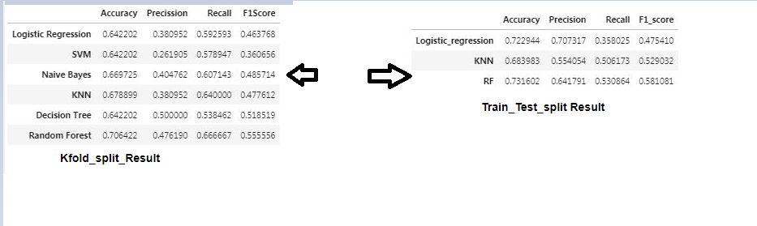

```python
image_import("Train_split vs K_fold_split.png")
```

**From the above comparison we can say that tarin_test_split with(stratify=y) also performing good ,Both the result is approximately similar**

**Parameter tunning of RandomForest Model**

```python
param_grid_kfold_rf = {
  'n_estimators': [100,200,300,400,500]
   ,"n_jobs":[1,2,3,4,5]
}
from sklearn.model_selection import GridSearchCV
# Instantiate the grid search model
grid_search_kfold_rf = GridSearchCV(estimator =Classifier_kfold_rf, param_grid = param_grid_kfold_rf)
```

```python
grid_search_kfold_rf.fit(X_train_fold,y_train_fold)
```

```
GridSearchCV(cv=None, error_score=nan,
             estimator=RandomForestClassifier(bootstrap=True, ccp_alpha=0.0,
                                              class_weight=None,
                                              criterion='gini', max_depth=None,
                                              max_features='auto',
                                              max_leaf_nodes=None,
                                              max_samples=None,
                                              min_impurity_decrease=0.0,
                                              min_impurity_split=None,
                                              min_samples_leaf=1,
                                              min_samples_split=2,
                                              min_weight_fraction_leaf=0.0,
                                              n_estimators=100, n_jobs=None,
                                              oob_score=False, random_state=42,
                                              verbose=0, warm_start=False),
             iid='deprecated', n_jobs=None,
             param_grid={'n_estimators': [100, 200, 300, 400, 500],
                         'n_jobs': [1, 2, 3, 4, 5]},
             pre_dispatch='2*n_jobs', refit=True, return_train_score=False,
             scoring=None, verbose=0)
```

```python
grid_search_kfold_rf.best_params_
```

```
{'n_estimators': 200, 'n_jobs': 1}
```

```python
param_grid_kfold_knn = {
  "n_neighbors":[5,7,9,10,13]
   ,"p":[1,2]
}
from sklearn.model_selection import GridSearchCV
# Instantiate the grid search model
grid_search_kfold_knn = GridSearchCV(estimator =Classifier_kfold_KNN, param_grid = param_grid_kfold_knn)
```

```python
grid_search_kfold_knn.fit(X_train_fold,y_train_fold)
```

```
GridSearchCV(cv=None, error_score=nan,
             estimator=KNeighborsClassifier(algorithm='auto', leaf_size=30,
                                            metric='minkowski',
                                            metric_params=None, n_jobs=None,
                                            n_neighbors=5, p=2,
                                            weights='uniform'),
             iid='deprecated', n_jobs=None,
             param_grid={'n_neighbors': [5, 7, 9, 10, 13], 'p': [1, 2]},
             pre_dispatch='2*n_jobs', refit=True, return_train_score=False,
             scoring=None, verbose=0)
```

```python
grid_search_kfold_knn.best_params_
```

```
{'n_neighbors': 13, 'p': 2}
```

# We will tune the KNN model

```python
from sklearn.neighbors import KNeighborsClassifier
Classifier_kfold_KNN_tune = KNeighborsClassifier(n_neighbors=grid_search_kfold_knn.best_params_['n_neighbors'],p=grid_search_kfold_knn.best_params_['p'])
Classifier_kfold_KNN_tune.fit(X_train_fold,y_train_fold)
```

```
KNeighborsClassifier(algorithm='auto', leaf_size=30, metric='minkowski',
                     metric_params=None, n_jobs=None, n_neighbors=13, p=2,
                     weights='uniform')
```

```python
y_pred_KNN_kfold_tune = Classifier_kfold_KNN_tune.predict(X_test_fold)
```

```python
from sklearn.metrics import confusion_matrix,accuracy_score,precision_score,recall_score,f1_score
cm_kfold_KNN_tune=confusion_matrix(y_pred_KNN_kfold_tune,y_test_fold)
accuracy_kfold_KNN_tune = accuracy_score(y_pred_KNN_kfold_tune,y_test_fold)
precision_kfold_KNN_tune =precision_score(y_pred_KNN_kfold_tune,y_test_fold)
recall_kfold_KNN_tune = recall_score(y_pred_KNN_kfold_tune,y_test_fold)
F1score_kfold_KNN_tune =f1_score(y_pred_KNN_kfold_tune,y_test_fold)
print(cm_kfold_KNN_tune)
print("Accuracy{} and Precission:{} and Recall:{} and F1score:{}".format(accuracy_kfold_KNN_tune,precision_kfold_KNN_tune,recall_kfold_KNN_tune,F1score_kfold_KNN_tune))
```

```
[[57 18]
 [10 24]]
Accuracy0.7431192660550459 and Precission:0.5714285714285714 and Recall:0.7058823529411765 and F1score:0.6315789473684211
```

# ROC Curve Analysis of Kfold split set

### ROC-Receiver Operating Characterestic curve

It is a very useful technique when predicting the probability binary classification ,it plots false positive rate on and true positive rate on y axis

# Diabetes prediction is very important issue becuase it affects the life

**True_Positive_rate = TP/(TP+FN)**

**Sensitivity == True_Positive_rate**

**False_Positive_rate = FP/(FP+TN)**

**Specificity=1-False_Positive_rate**

```python
from sklearn.metrics import roc_curve
from sklearn.metrics import roc_auc_score
# generate a no skill prediction (majority class)
ns_probs = [0 for _ in range(len(y_test_fold))]
```

```python
rf_probabs = Classifier_kfold_rf.predict_proba(X_test_fold)
```

```python
rf_probabs =rf_probabs[:,1]
```

```python
ns_auc = roc_auc_score(y_test_fold, ns_probs)
rf_auc = roc_auc_score(y_test_fold, rf_probabs)
```

```python
print('No Skill: ROC AUC=%.3f' % (ns_auc))
print('RF: ROC AUC=%.3f' % (rf_auc))
```

```
No Skill: ROC AUC=0.500
RF: ROC AUC=0.800
```

```python
ns_fpr, ns_tpr, _ = roc_curve(y_test_fold, ns_probs)
rf_fpr, rf_tpr, _ = roc_curve(y_test_fold, rf_probabs)
```

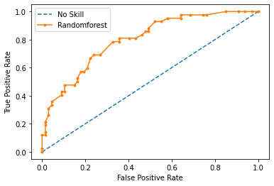

```python
plt.plot(ns_fpr, ns_tpr, linestyle='--', label='No Skill');
plt.plot(rf_fpr, rf_tpr, marker='.', label='Randomforest');
plt.xlabel('False Positive Rate')
plt.ylabel('True Positive Rate')
# show the legend
plt.legend()

# show the plot
plt.show();
```

# Running the example will predict ROC AUC Curve predict 0 for all the case

# KNN

```python
KNN_probabs = Classifier_kfold_KNN.predict_proba(X_test_fold)
```

```python
KNN_probabs=KNN_probabs[:,1]
```

```python
ns_auc = roc_auc_score(y_test_fold, ns_probs)
KNN_auc = roc_auc_score(y_test_fold, KNN_probabs)
```

```python
print('No Skill: ROC AUC=%.3f' % (ns_auc))
print('KNN: ROC AUC=%.3f' % (KNN_auc))
```

```
No Skill: ROC AUC=0.500
KNN: ROC AUC=0.760
```

```python
ns_fpr, ns_tpr, _ = roc_curve(y_test_fold, ns_probs)
KNN_fpr, KNN_tpr, _ = roc_curve(y_test_fold, KNN_probabs)
```

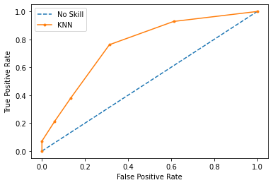

```python
plt.plot(ns_fpr, ns_tpr, linestyle='--', label='No Skill');
plt.plot(KNN_fpr, KNN_tpr, marker='.', label='KNN');
plt.xlabel('False Positive Rate')
plt.ylabel('True Positive Rate')
# show the legend
plt.legend()
# show the plot
plt.show();
```

## ROC Curve Analysis for Train-Test split

```
No Skill: ROC AUC=0.500
LR: ROC AUC=0.759
```

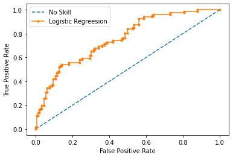

```python
ns_probs = [0 for _ in range(len(y_test))]
Classification_lr = final_logistic_regression.predict_proba(X_test)
Classification_lr = Classification_lr[:,1]
ns_auc = roc_auc_score(y_test, ns_probs)
lr_auc = roc_auc_score(y_test,Classification_lr)
print('No Skill: ROC AUC=%.3f' % (ns_auc))
print('LR: ROC AUC=%.3f' % (lr_auc))
ns_fpr, ns_tpr, _ = roc_curve(y_test, ns_probs)
lr_fpr, lr_tpr, _ = roc_curve(y_test, Classification_lr)
plt.plot(ns_fpr, ns_tpr, linestyle='--', label='No Skill');
plt.plot(lr_fpr, lr_tpr, marker='.', label='Logistic Regreesion');
plt.xlabel('False Positive Rate')
plt.ylabel('True Positive Rate')
# show the legend
plt.legend()
# show the plot
plt.show();
```

```
No Skill: ROC AUC=0.500
knn: ROC AUC=0.732
```

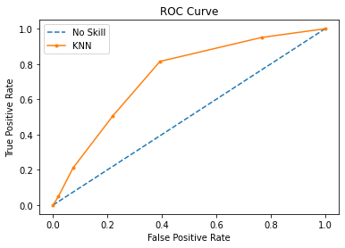

```python
ns_probs = [0 for _ in range(len(y_test))]
Classification_knn = Classifier_tt_KNN.predict_proba(X_test)
Classification_knn = Classification_knn[:,1]
ns_auc = roc_auc_score(y_test, ns_probs)
knn_auc = roc_auc_score(y_test,Classification_knn)
print('No Skill: ROC AUC=%.3f' % (ns_auc))
print('knn: ROC AUC=%.3f' % (knn_auc))
ns_fpr, ns_tpr, _ = roc_curve(y_test, ns_probs)
lr_fpr, lr_tpr, _ = roc_curve(y_test, Classification_knn)
plt.plot(ns_fpr, ns_tpr, linestyle='--', label='No Skill');
plt.plot(lr_fpr, lr_tpr, marker='.', label='KNN');
plt.xlabel('False Positive Rate')
plt.ylabel('True Positive Rate')
plt.title("ROC Curve")
# show the legend
plt.legend()
# show the plot
plt.show();
```

## We saw from the above calulation that we did not get very high accuracy but becuase model is facing bias problem but we did well to reduce type 2 error we can improve our model with new features

## Tableau Dashboard

[Click here](https://public.tableau.com/profile/mayank.mishra4078#!/vizhome/NIDK_dataset/DiabetesAnalysis?publish=yes) for detail Tableau Dashboard

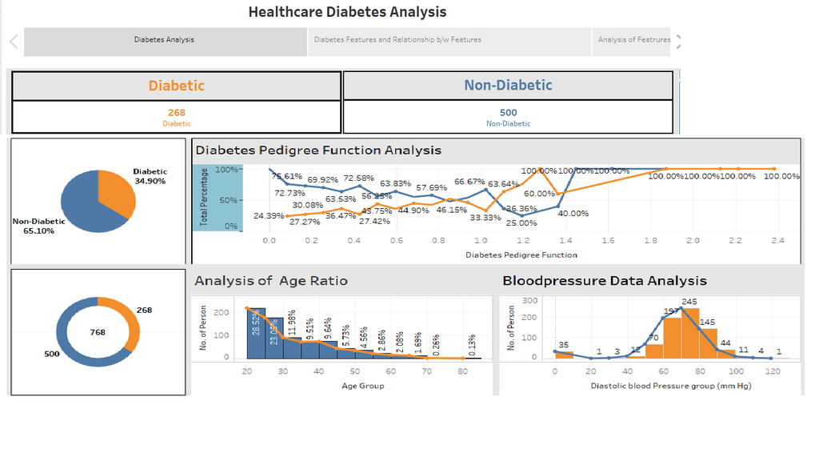

```python
image_import("Dashboard.png")
```

## Hello team I created the Diabetes predictor AI App please check and Provide your variable review

[Click here](http://ec2-52-14-135-60.us-east-2.compute.amazonaws.com:8080/) for App review

**Below is the Image of App**

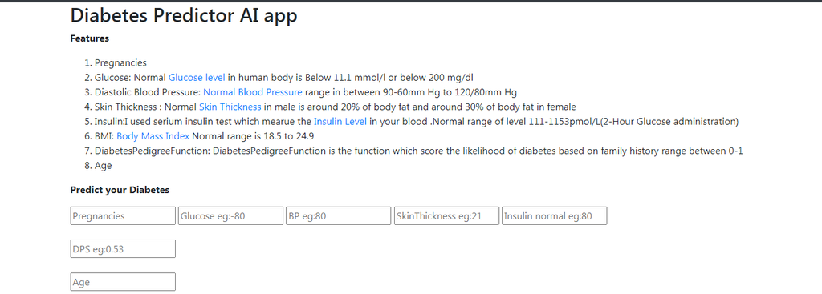

```python
image_import("app_image.png")
```